# nkelley_FinalHomeworkCode_04

Natalia Kelley

# Preliminaries

Load the following packages:

```r
library(curl)
```

```r
library(ggplot2)
library(tidyverse)
library(gridExtra)
library(manipulate)
library(lmodel2)
```

# Part One: Writing a Function

Write a simple R function, Z.prop.test(), that can perform one- or two-sample Z-tests for proportion data

```r
Z.prop.test <- function(p1, n1, p2 = NULL, n2 = NULL, p0, alternative = "two.sided", conf.level = 0.95)
#specifies arguments
{
    pstar <- ((p2*n2)+(p1*n1))/(n1 + n2)
#pstar is the pooled proportion for both samples

    if((n1 * p1 > 5) == FALSE || (n1 * (1-p1) > 5) == FALSE || (n2 * p2 > 5) == FALSE || (n2 * (1-p2) > 5) == FALSE) {
    warning("normal distribution invalid")}
#here specify that if (\(n * p > 5\) and \(n * (1-p) > 5\)) untrue, run function but print error message that assumptions aren't met.

  if(alternative == "two.tailed"){
  Z <- (p2-p1-p0)/(sqrt(pstar(1-pstar)(1/n1 + 1/n2)))
  print(Z)
#Z test statistic for two-sample Z test
  P <- 1 - pnorm(Z, lower.tail = TRUE) + pnorm(Z, lower.tail = FALSE)
  print(P)
#p value for two-sample Z test
lower <- ((p2-p1)-qnorm(conf.level) * sqrt((p2-p1)*(1-(p2-p1)))/n1)
upper <- ((p2-p1)+qnorm(conf.level) * sqrt((p2-p1)*(1-(p2-p1)))/n1)
     CI <- c(lower, upper)
#confidence interval based on normal distribution
}

  if(alternative == "less"){
        Z <- (p2-p1)/(sqrt(pstar(1-pstar)(1/n1 + 1/n2)))
#z for p1<p2
    P <- pnorm(Z, lower.tail = TRUE)
#p for p1<p2
    lower <- ((p2-p1)-qnorm(conf.level) * sqrt((p2-p1)*(1-(p2-p1)))/n1) # ci intervals
upper <- ((p2-p1)+qnorm(conf.level) * sqrt((p2-p1)*(1-(p2-p1)))/n1)
     CI <- c(lower, upper)
#CI for p1<p2
}
#two sample, p1<p2

  if(alternative == "greater"){
    Z <- (p1-p2)/(sqrt(pstar(1-pstar)(1/n1 + 1/n2)))
# z for p1>p2
    P <- pnorm(Z, lower.tail = FALSE)
#p for pw>p2
      lower <- ((p1-p2)-qnorm(conf.level) * sqrt((p1-p2)*(1-(p1-p2)))/n1)
upper <- ((p1-p2)+qnorm(conf.level) * sqrt((p1-p2)*(1-(p1-p2)))/n1)
     CI <- c(lower, upper)
#confidence interval for p1>p2 test
}
#this calcuates one-sided p value of p1>p2

  if(is.null(p2) || is.null(n2)){
    Z <- (p1-p0)/(sqrt(p0(1-p0)/n1))
#Z statistic for one-sample Z test
    P <- pnorm(Z, two.sided = TRUE)
#p value associated with Z for one-sample Z test
    lower <- p1 - qnorm(conf.level) * sqrt(p1 * (1 - p1)/n1)
    upper <- p1 + qnorm(conf.level) * sqrt(p1 * (1 - p1)/n1)
CI <- c(lower, upper)
#CI for one-sample Z test
}
#here if p2 or n2 or both is NULL, perform one-sample Z test. "||" means [or](http://applied-r.com/conditionals-in-r/)

values <- c(Z, P, CI)
print(values)

}
 # end of function
```

From Abby: cat( “Z_score =”, Z.two.sample <- Z.two.sample, “”, “CI =”, CI.two.sample <- CI.two.sample, “”, “P-Value =”, P.Value <- P.Value, “”) }

# Part Two: Regression

The dataset from Kamilar and Cooper has in it a large number of variables related to life history and body size. For this exercise, the end aim is to fit a simple linear regression model to predict longevity (MaxLongevity_m) measured in months from species’ brain size (Brain_Size_Species_Mean) measured in grams. Do the following for both longevity~brain size and log(longevity)~log(brain size):

```r
f <- curl("https://raw.githubusercontent.com/fuzzyatelin/fuzzyatelin.github.io/master/AN588_Fall21/KamilarAndCooperData.csv")

c <- read.csv(f, header = TRUE, sep = ",", stringsAsFactors = FALSE)
#creates data frame from raw csv file

d <- na.omit(c)
```

## Fit Regression and Produce Scatterplot

Fit the regression model and, using {ggplot2}, produce a scatterplot with the fitted line superimposed upon the data. Append the the fitted model equation to your plot (HINT: use the function geom_text()).

```r
#normal variables
y <- d$MaxLongevity_m
x <- d$Brain_Size_Species_Mean

m <- lm(y~x, data = d)
summary(m)
```

```
##
## Call:
## lm(formula = y ~ x, data = d)
##
## Residuals:
##      Min       1Q   Median       3Q      Max
## -152.498  -73.422   -4.425   72.430  285.749
##
## Coefficients:
##             Estimate Std. Error t value Pr(>|t|)
## (Intercept) 307.7522    27.8459  11.052 6.73e-11 ***
## x             0.8789     0.1672   5.256 2.18e-05 ***
## ---
## Signif. codes:  0 '***' 0.001 '**' 0.01 '*' 0.05 '.' 0.1 ' ' 1
##
## Residual standard error: 98.31 on 24 degrees of freedom
## Multiple R-squared:  0.5351, Adjusted R-squared:  0.5158
## F-statistic: 27.63 on 1 and 24 DF,  p-value: 2.176e-05
```

```r
t <- coef(summary(m))
t <- data.frame(unlist(t))
colnames(t) <- c("Est", "SE", "t", "p")
t
```

```
##                     Est         SE         t            p
## (Intercept) 307.7522151 27.8458691 11.051988 6.731540e-11
## x             0.8789037  0.1672169  5.256071 2.175887e-05
```

```r
#this equation is used to add linear regression equation and r2 to ggplot later
eq <- function(x,y) {
  m <- lm(y ~ x)
  as.character(
    as.expression(
      substitute(italic(y) == a + b %.% italic(x)*","~~italic(r)^2~"="~r2,
                list(a = format(coef(m)[1], digits = 4),
                b = format(coef(m)[2], digits = 4),
                r2 = format(summary(m)$r.squared, digits = 3)))
    )
  )
}

#log variables
ly <- log(d$MaxLongevity_m)
lx <- log(d$Brain_Size_Species_Mean)

ml <- lm(ly~lx, data = d)
ml
```

```
##
## Call:
## lm(formula = ly ~ lx, data = d)
##
## Coefficients:
## (Intercept)           lx
##      5.0865       0.2029
```

```r
summary(ml)
```

```
##
## Call:
## lm(formula = ly ~ lx, data = d)
##
## Residuals:
##      Min       1Q   Median       3Q      Max
## -0.43044 -0.18029 -0.01211  0.17548  0.53196
##
## Coefficients:
##             Estimate Std. Error t value Pr(>|t|)
## (Intercept)  5.08650    0.22413  22.694  < 2e-16 ***
## lx           0.20285    0.05002   4.055 0.000458 ***
## ---
## Signif. codes:  0 '***' 0.001 '**' 0.01 '*' 0.05 '.' 0.1 ' ' 1
##
## Residual standard error: 0.2539 on 24 degrees of freedom
## Multiple R-squared:  0.4066, Adjusted R-squared:  0.3819
## F-statistic: 16.44 on 1 and 24 DF,  p-value: 0.0004583
```

```r
lt <- coef(summary(ml))
lt <- data.frame(unlist(lt))
colnames(lt) <- c("Est", "SE", "t", "p")
lt
```

```
##                   Est         SE         t            p
## (Intercept) 5.0864977 0.22413403 22.694001 9.993694e-18
## lx          0.2028543 0.05002379  4.055156 4.583151e-04
```

```r
leq <- function(lx,ly) {
  ml <- lm(ly ~ lx)
  as.character(
    as.expression(
      substitute(italic(ly) == a + b %.% italic(lx)*","~~italic(r)^2~"="~r2,
                list(a = format(coef(ml)[1], digits = 4),
                b = format(coef(ml)[2], digits = 4),
                r2 = format(summary(ml)$r.squared, digits = 3)))
    )
  )
}
```

eq() from https://www.roelpeters.be/how-to-add-a-regression-equation-and-r-squared-in-ggplot2/

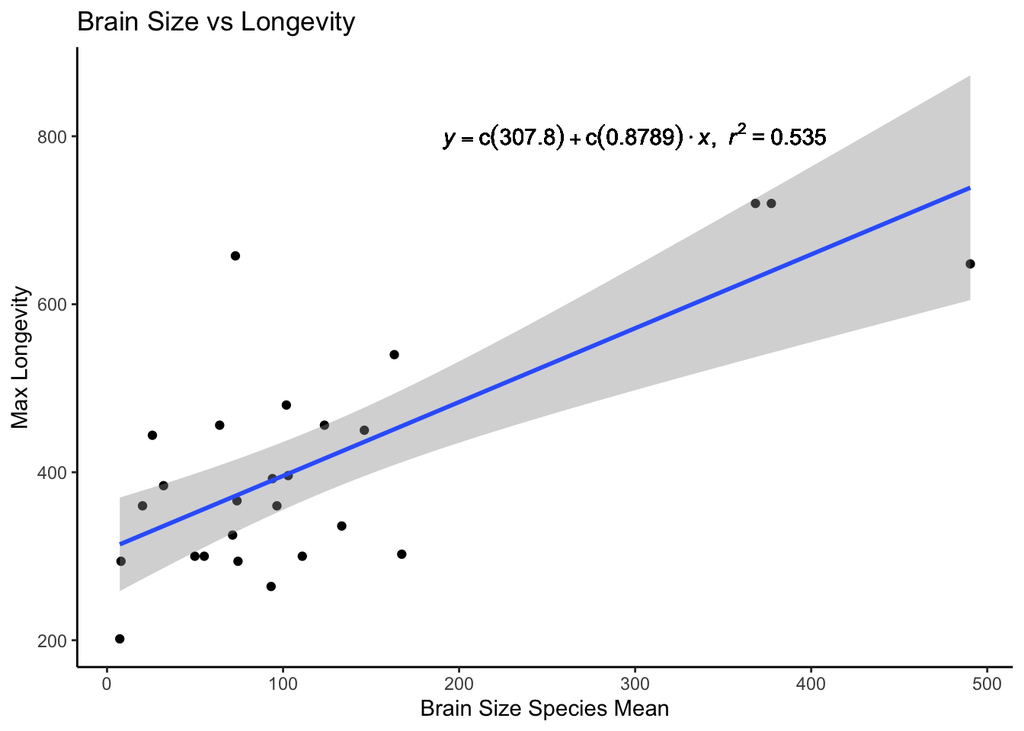

```r
#for normal
g <- ggplot(data = d, aes(x = x, y = y)) +
  geom_point() +
  geom_smooth(method = "lm", formula = y ~ x) +
  geom_text(x = 300, y = 800, label = eq(x, y), parse = TRUE) +
  labs(x = "Brain Size Species Mean", y = "Max Longevity", title = "Brain Size vs Longevity") +
  theme_classic()
g
```

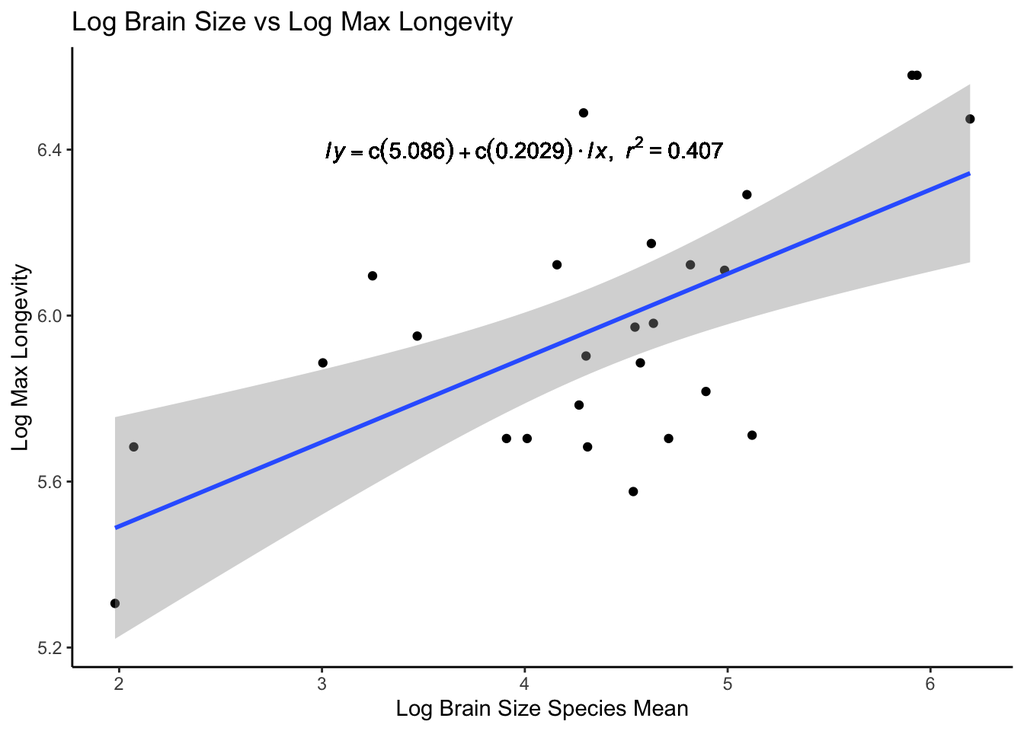

```r
#for log
lg <- ggplot(data = d, aes(x = lx, y = ly)) +
  geom_point() +
  geom_smooth(method = "lm", formula = y ~ x)  +
  geom_text(x = 4, y = 6.4, label = leq(lx, ly), parse = TRUE) +
  labs(x = "Log Brain Size Species Mean", y = "Log Max Longevity", title = "Log Brain Size vs Log Max Longevity") + theme_classic()
lg
```

**Notes from Class** add equation: victoria’s package: stat_poly_eq(formula = y ~ x, aes(label = paste(..eq.label.., ..rr.label.., sep = “*plain(",")~“)), parse = TRUE) requires library(ggpmisc)

for legend: ggplot2 theme command

for colors: scale_color_manual(name = “Intervals - 90%”, values=c(“Confidence” = “#FF6600”, “Prediction” = “#000066”))

## Slope Estimate with Hypothesis Test and CI

Identify and interpret the point estimate of the slope ($\beta_1$), as well as the outcome of the test associated with the hypotheses H0: $\beta_1$ = 0; HA: $\beta_1$ ≠ 0. Also, find a 90 percent CI for the slope ($\beta_1$) parameter.

```r
t1 <- unlist(m$coefficients)
# normal
beta0<- t$Est[1]
beta0
```

```
## [1] 307.7522
```

```r
beta1 <- t$Est[2]
beta1
```

```
## [1] 0.8789037
```

```r
ci.slope <- confint(m, level=0.90)
ci.slope
```

```
##                     5 %       95 %
## (Intercept) 260.1112167 355.393214
## x             0.5928154   1.164992
```

```r
# log

lbeta0<- lt$Est[1]
lbeta0
```

```
## [1] 5.086498
```

```r
lbeta1 <- lt$Est[2]
lbeta1
```

```
## [1] 0.2028543
```

```r
lci.slope <- confint(ml, level=0.90)
lci.slope
```

```
##                   5 %      95 %
## (Intercept) 4.7030309 5.4699646
## lx          0.1172695 0.2884391
```

## 90% CI Lines and PI Bands

Using your model, add lines for the 90 percent confidence and prediction interval bands on the plot and add a legend to differentiate between the lines.

```r
#normal
ci <- predict(m, newdata = data.frame(Brain_Size_Species_Mean = x), interval = "confidence", level = 0.90)

pi <- predict(m, newdata = data.frame(Brain_Size_Species_Mean = x), interval = "prediction", level = 0.90)

df <- data.frame(cbind(x, y, ci, pi))
names(df) <- c("x", "y", "CIfit", "CIlower", "CIupper", "PIfit", "PIlower", "PIupper")
head(df)
```

```
##       x     y    CIfit  CIlower  CIupper    PIfit  PIlower  PIupper
## 1 49.88 300.0 351.5919 312.9621 390.2217 351.5919 179.0151 524.1688
## 2 55.22 300.0 356.2853 318.4280 394.1425 356.2853 183.8797 528.6908
## 3  7.24 201.6 314.1155 267.9467 360.2843 314.1155 139.6963 488.5347
## 4 72.93 657.6 371.8507 336.2051 407.4962 371.8507 199.9172 543.7841
## 5 71.33 325.2 370.4444 334.6229 406.2659 370.4444 198.4744 542.4144
## 6 74.39 294.0 373.1339 337.6445 408.6232 373.1339 201.2328 545.0350
```

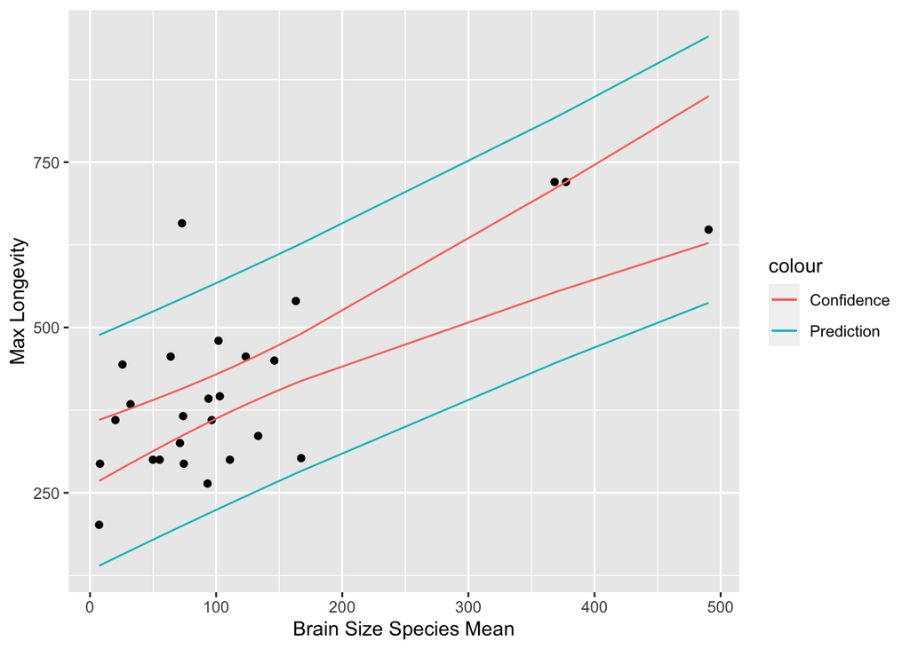

```r
g1 <- ggplot(df, aes(x = x, y = y)) +
  geom_point() +
  geom_line(data = df, aes(x = x, y = CIlower, col = "Confidence")) +
  geom_line(data = df, aes(x = x, y = CIupper, col = "Confidence")) +
  geom_line(data = df, aes(x = x, y = PIlower, col = "Prediction")) +
  geom_line(data = df, aes(x = x, y = PIupper, col = "Prediction")) +
  labs(x = "Brain Size Species Mean",
         y = "Max Longevity")
g1
```

```r
#log
lci <- predict(ml, newdata = data.frame(x = lx), interval = "confidence", level = 0.90)

lpi <- predict(ml, newdata = data.frame(x = lx), interval = "prediction", level = 0.90)

ldf <- data.frame(cbind(lx, ly, lci, lpi))
names(ldf) <- c("lx", "ly", "CIfit", "CIlower", "CIupper", "PIfit", "PIlower", "PIupper")
head(ldf)
```

```
##         lx       ly    CIfit  CIlower  CIupper    PIfit  PIlower  PIupper
## 1 3.909620 5.703782 5.879581 5.785763 5.973399 5.879581 5.435127 6.324035
## 2 4.011325 5.703782 5.900212 5.809692 5.990732 5.900212 5.456443 6.343982
## 3 1.979621 5.306286 5.488072 5.266574 5.709571 5.488072 5.000426 5.975719
## 4 4.289500 6.488597 5.956641 5.871172 6.042110 5.956641 5.513874 6.399408
## 5 4.267317 5.784440 5.952141 5.866501 6.037781 5.952141 5.509341 6.394941
## 6 4.309322 5.683580 5.960662 5.875311 6.046013 5.960662 5.517918 6.403406
```

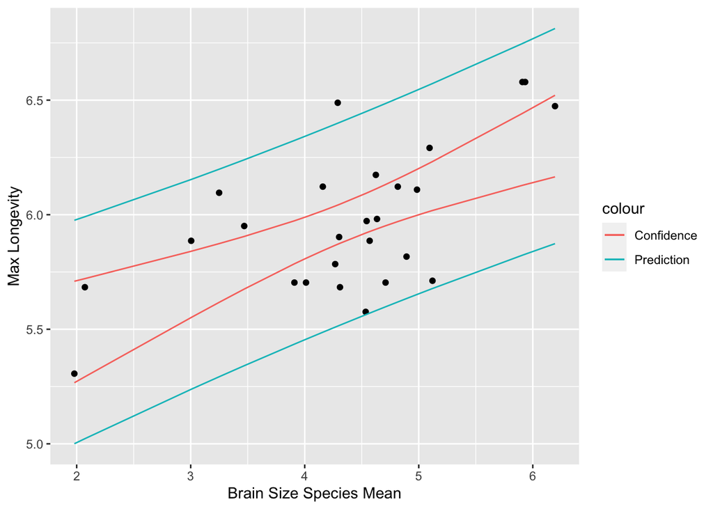

```r
lg1 <- ggplot(data = ldf, aes(x = lx, y = ly)) +
  geom_point()+
  geom_line(data = ldf, aes(x = lx, y = CIlower, colour = "Confidence")) +
  geom_line(data = ldf, aes(x = lx, y = CIupper, colour = "Confidence")) +
  geom_line(data = ldf, aes(x = lx, y = PIlower, colour = "Prediction")) +
  geom_line(data = ldf, aes(x = lx, y = PIupper, colour = "Prediction")) +
  labs(x = "Brain Size Species Mean",
         y = "Max Longevity")
lg1
```

## Point Estimate with 90% PI

Produce a point estimate and associated 90 percent PI for the longevity of a species whose brain weight is 800 gm. Do you trust the model to predict observations accurately for this value of the explanatory variable? Why or why not?

```r
#normal
predict(m, newdata = data.frame(x = 800))
```

```
##        1
## 1010.875
```

```r
#point estimate

predict(m, newdata = data.frame(x = 800), interval = "prediction", level = 0.90)
```

```
##        fit     lwr      upr
## 1 1010.875 751.631 1270.119
```

```r
#PI

#log
predict(ml, newdata = data.frame(lx = log(800)))
```

```
##      1
## 6.4425
```

```r
#point estimate

predict(ml, newdata = data.frame(lx = log(800)), interval = "prediction", level = 0.90)
```

```
##      fit      lwr      upr
## 1 6.4425 5.957435 6.927564
```

```r
#PI
```

This is an extrapolation, and the r^2 associated with this extrapolation is very low, so I would not trust this prediction. The r^2 for my log predictions is lower though, which is not the expected result. I was expecting the log to be more reliable. I think something may have gone wrong, but I can’t figure out what.

## Model Comparison

**Looking at your two models, which do you think is better? Why?**

I expected the first model to be worse than the log model, but the r^2 for my log model is lower, which is unexpected. I was expecting the log to be more reliable. I think something may have gone wrong, but I can’t figure out what.

# Challenges

1. My prediction lines look very messed up. I think they should be smooth, but I can’t figure out what went wrong. *Update: when I submitted this, the lines were still messed up. I eventually went back and sifted through until I found the issue (x~y vs y~x discrepancies in my code).
2. I’m having trouble getting a legend to appear for the different prediction line colors. *Update: while doing my data replication, I learned I could assign categories (ex. prediction vs confidence) rather than colors, and this would automatically assign colors and add an appropriate legend. I added this in here for clarity.
3. My log model is not giving the expected results, so I’m concerned something went wrong.